# Image_classification_using_CNNs_in_Keras

## Project - Image classification using CNNs in Keras

```
- Amarpreet Bassan
```

### Assumptions

- This notebook is running on Jupyter Colab environment
- The data file : images.py and Labels.csv is stored in a folder named ConvNetProject in the google drive.
- This notebook is also present inside the same directory in the google drive.

### Configuration for Executing this project:

- Create a folder named : ConvNetProject in your google drive.
- Copy the data files : images.npy and Labels.csv and this notebook inside that folder.
- Execute this notebook from the folder .

## Tables of Content

- Objective 1
  - Mounting the Google Drive
  - Observations for Objective1
- Objective 2 - Data Preprocessing
  - Normalizing the data
  - Converting to GrayScale
  - Observations for Objective2 -Objective 3 - Data Preparation Section
  - Observations for Objective 3
- Objective 4 - Building CNN Model
- Objective 5 - Fit and Evaluate CNN Model
  - Confusion Matrix -Observations for Objective 5
- Objective 6 - Visualize Predictions

```python
from google.colab import drive
drive.mount('/content/drive')
```

```python
#Importing the required Libraries
import cv2
#from google.collab.patches import cv2_imshow
import numpy as np
import matplotlib.pyplot as plt
%matplotlib inline
import pandas as pd

from tensorflow.keras import models, layers, optimizers
from tensorflow.keras.preprocessing.image import ImageDataGenerator
from tensorflow.keras.callbacks import ModelCheckpoint, EarlyStopping
from sklearn.preprocessing import OneHotEncoder
from sklearn.model_selection import train_test_split
from sklearn.metrics import confusion_matrix
from sklearn import metrics
```

```python
#lets read the data
imagedataabt = np.load('/content/drive/My Drive/ConvNetProject/images.npy')
imagelabelabt = pd.read_csv('/content/drive/My Drive/ConvNetProject/Labels.csv')
```

```python
#Make a copy fo the data
imagedataworkingcopy = imagedataabt.copy()
imagelabelworkingcopy = imagelabelabt.copy()
```

```python
#print the shape of the data
print("shape of the image array:")
imagedataworkingcopy.shape
```

```
shape of the image array:
```

```
(4750, 128, 128, 3)
```

```python
print("The shape of the label data:")
imagelabelworkingcopy.shape
```

```
The shape of the label data:
```

```
(4750, 1)
```

```
Label
 Label Index: 2105
 Name: Charlock
```

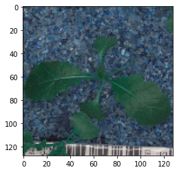

```
Label
 Label Index: 2209
 Name: Charlock
```

[figure not shown]

```
Label
 Label Index: 494
 Name: Small-flowered Cranesbill
```

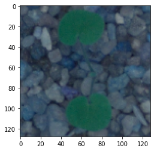

```
Label
 Label Index: 1824
 Name: Common Chickweed
```

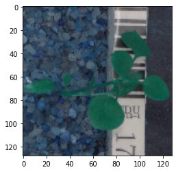

```
Label
 Label Index: 3189
 Name: Scentless Mayweed
```

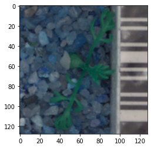

```python
#let us visualize any 5 images  within 4750

for i in range(5):
    index = np.random.randint(0, 4750)
    image = imagedataworkingcopy[index]
    label = imagelabelworkingcopy.iloc[index][0]
    print('Label \n Label Index: {label} \n Name: {label_name}'.format(label = index, label_name = label))
    plt.imshow(image)
    plt.show()
```

## Observations for Objective 1:

Table of Content

- Image array has the shape : (4750, 128, 128, 3)
  - Images are 128 * 128 with rbg scale.
- Labels are of the following shape: (4750, 1)
  - Labels correspond to the images in the array.

## Data Preprocessing Section - Objective 2

Table of Content

```python
# Sequential model expects the model in ths shape (number of examples, height, width and channels)
# our dataset is already in this shape.
# Normalize the data so that the values are between 0 and 1
#create two vectors x and y as follows:

x = imagedataworkingcopy.copy()
y = imagelabelworkingcopy.copy()
```

```python
type(x)
```

```
numpy.ndarray
```

##### Normalizing the data

Table of Content

```python
x = x.astype('float32')
x /= 255
```

[output not shown]

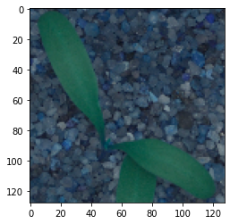

```python
# let us visualize the image 3389 after normalization
i = 3315
print(x.shape)
imge = x[i]
lbl = y.iloc[i][0]
print('Label \n Label Index: {label} \n Name: {label_name}'.format(label = i, label_name = lbl))
print(x[i])
plt.imshow(imge)
plt.show()
```

##### Conversion of data to grayscale

Table of Content

```python
#we will convert the image to grayscale
x_gray = np.ndarray((x.shape[0], x.shape[1], x.shape[2]))
try:
  for numimage in range(x.shape[0]):
    x_gray[numimage] = cv2.cvtColor(x[numimage], cv2.COLOR_BGR2GRAY)
except Exception as ex:
  print(ex)
  print(numimage)
```

```python
x_gray[3315]
```

```
array([[0.34119219, 0.31889415, 0.26544708, ..., 0.29317647, 0.29121178,
        0.13971373],
       [0.259     , 0.31462356, 0.30481571, ..., 0.30123138, 0.13574903,
        0.16959217],
       [0.37599999, 0.38373727, 0.37544706, ..., 0.15062746, 0.25420392,
        0.1367255 ],
       ...,
       [0.24818432, 0.24498826, 0.15621962, ..., 0.46440002, 0.47616473,
        0.41701961],
       [0.30551374, 0.27700001, 0.27171373, ..., 0.47884709, 0.48765099,
        0.45016474],
       [0.31032944, 0.29261962, 0.29937649, ..., 0.46606278, 0.46463531,
        0.44916078]])
```

```python
x_gray.shape
```

```
(4750, 128, 128)
```

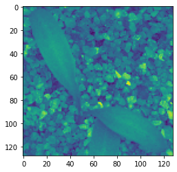

```python
plt.imshow(x_gray[3315])
```

```python
#let us introduce guassian blurring to reduce the noise now.
x_blurred = np.ndarray((x.shape[0], x.shape[1], x.shape[2]))
try:
  for numimage in range(x.shape[0]):
    x_blurred[numimage] = cv2.GaussianBlur(x_gray[numimage], (7, 7), 0)
except Exception as ex:
  print(ex)
```

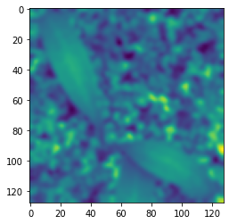

```python
#let us check the blurred image:
plt.imshow(x_blurred[3315])
```

## Observations for Objective 2:

Table of Content

- We normalized the image array by dividing the elements by 255.
- We also converted the image to Grayscale.
- We also added blurring to the image using guassian blurring and kernel of 7, 7

## Objective 3 - Data Preparation Section

Table of Content

```python
#we use pd.get_dummies for one hot encoding

y_categorical = pd.get_dummies(y)
```

```python
y_categorical
```

|  | Label_Black-grass | Label_Charlock | Label_Cleavers | Label_Common Chickweed | Label_Common wheat | Label_Fat Hen | Label_Loose Silky-bent | Label_Maize | Label_Scentless Mayweed | Label_Shepherds Purse | Label_Small-flowered Cranesbill | Label_Sugar beet |
| --- | --- | --- | --- | --- | --- | --- | --- | --- | --- | --- | --- | --- |
| 0 | 0 | 0 | 0 | 0 | 0 | 0 | 0 | 0 | 0 | 0 | 1 | 0 |
| 1 | 0 | 0 | 0 | 0 | 0 | 0 | 0 | 0 | 0 | 0 | 1 | 0 |
| 2 | 0 | 0 | 0 | 0 | 0 | 0 | 0 | 0 | 0 | 0 | 1 | 0 |
| 3 | 0 | 0 | 0 | 0 | 0 | 0 | 0 | 0 | 0 | 0 | 1 | 0 |
| 4 | 0 | 0 | 0 | 0 | 0 | 0 | 0 | 0 | 0 | 0 | 1 | 0 |
| ... | ... | ... | ... | ... | ... | ... | ... | ... | ... | ... | ... | ... |
| 4745 | 0 | 0 | 0 | 0 | 0 | 0 | 1 | 0 | 0 | 0 | 0 | 0 |
| 4746 | 0 | 0 | 0 | 0 | 0 | 0 | 1 | 0 | 0 | 0 | 0 | 0 |
| 4747 | 0 | 0 | 0 | 0 | 0 | 0 | 1 | 0 | 0 | 0 | 0 | 0 |
| 4748 | 0 | 0 | 0 | 0 | 0 | 0 | 1 | 0 | 0 | 0 | 0 | 0 |
| 4749 | 0 | 0 | 0 | 0 | 0 | 0 | 1 | 0 | 0 | 0 | 0 | 0 |

4750 rows × 12 columns

```python
#we will split the data now into train , test with test_size = 0.30
x_train, x_testval, y_train, y_testval = train_test_split(x_blurred, y_categorical, test_size = 0.30, random_state = 42)
```

```python
#we will further divide the test into test and validation set
x_test, x_validation, y_test, y_validation = train_test_split(x_testval, y_testval, test_size = 0.5, random_state = 42)
```

##### Label for y_train[0]

Table of Content

```python
y_train.iloc[0, :]
```

```
Label_Black-grass                  0
Label_Charlock                     0
Label_Cleavers                     1
Label_Common Chickweed             0
Label_Common wheat                 0
Label_Fat Hen                      0
Label_Loose Silky-bent             0
Label_Maize                        0
Label_Scentless Mayweed            0
Label_Shepherds Purse              0
Label_Small-flowered Cranesbill    0
Label_Sugar beet                   0
Name: 2710, dtype: uint8
```

```python
#check the shape of x_test, x_train, x_validation
print("shape of x_train before reshaping")
print(x_train.shape)
print("shape of x_test before reshaping")
print(x_test.shape)
print("shape of x_validation before reshaping")
print(x_validation.shape)
```

```
shape of x_train before reshaping
(3325, 128, 128)
shape of x_test before reshaping
(712, 128, 128)
shape of x_validation before reshaping
(713, 128, 128)
```

```python
#reshaping to fit the sequential model of keras:
x_train = x_train.reshape(x_train.shape[0], 128, 128, 1)
x_test = x_test.reshape(x_test.shape[0], 128, 128, 1)
x_validation = x_validation.reshape(x_validation.shape[0], 128, 128, 1)
```

```python
#check the shape of x_test, x_train, x_validation
print("shape of x_train after reshaping")
print(x_train.shape)
print("shape of x_test after reshaping")
print(x_test.shape)
print("shape of x_validation after reshaping")
print(x_validation.shape)
```

```
shape of x_train after reshaping
(3325, 128, 128, 1)
shape of x_test after reshaping
(712, 128, 128, 1)
shape of x_validation after reshaping
(713, 128, 128, 1)
```

## Observations for Objective 3:

Table of Content

- We Changed the labels to one hot encoding using pd.get_dummies
- We split the dataset into test, validation and train set.
- We reshaped the data into the shape(nrows, height, width, number of channels)